# Divvy 2019-2020 Ridership Analysis

Jason Donner

2025-05-29

```r
knitr::opts_chunk$set(
  echo = FALSE,      # hide code chunks by default for stakeholders
  message = FALSE,
  warning = FALSE,
  fig.width = 8,
  fig.height = 5,
  dpi = 300)
```

## 2 Methodology

**Data sources** Divvy bike-share trip data for 2019 and 2020, downloaded as CSV files.

**Data preparation steps**

1. Standardized column names to the 2020 schema.
2. Stacked quarterly files, dropping deprecated latitude/longitude and demographic columns.
3. Cleaned member type labels and removed outlier/maintenance trips.
4. Added calendar fields (date, weekday) and calculated `ride_length`.

## 3 Key Findings

### 3.1 Ride Length Comparison

Average and Median Ride Duration by User Type

| User Type | Average Duration | Median Duration | Ride Count |
| --- | --- | --- | --- |
| casual | 89.5 | 23.2 | 67877 |
| member | 13.3 | 8.5 | 720312 |

### 3.2 Ride Volume by Weekday

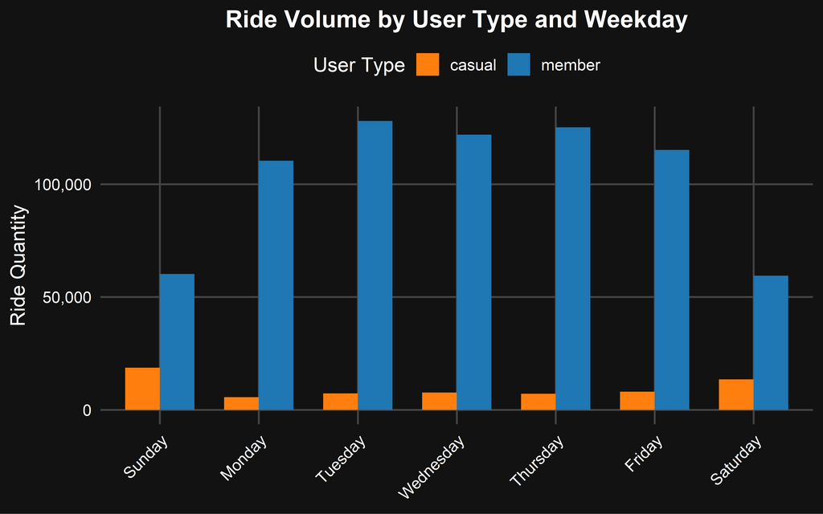

### 3.3 Average Duration by Weekday

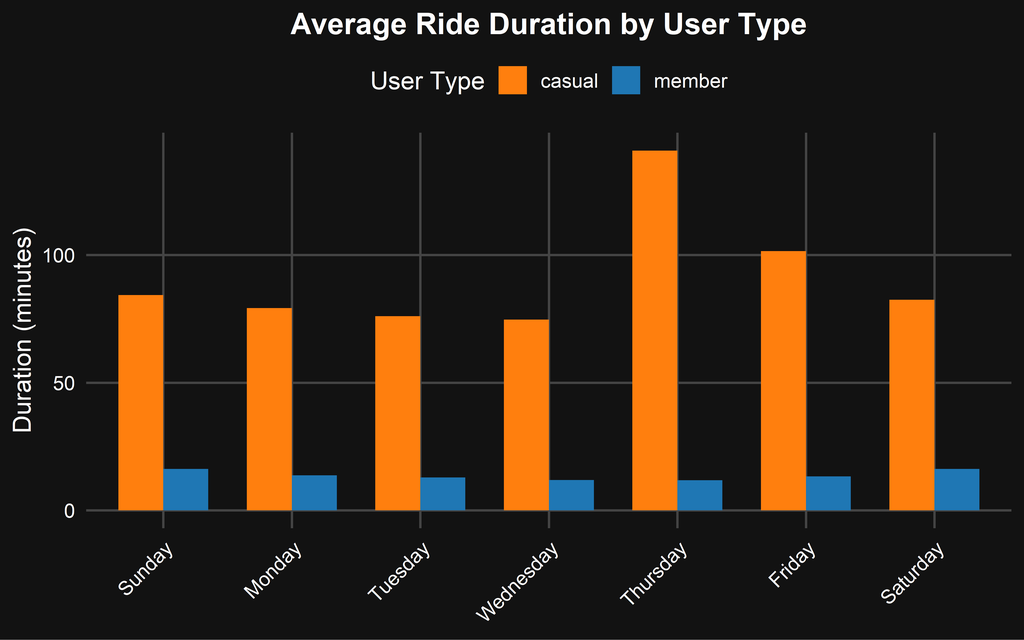

### 3.4 Ride Start-Time Distribution

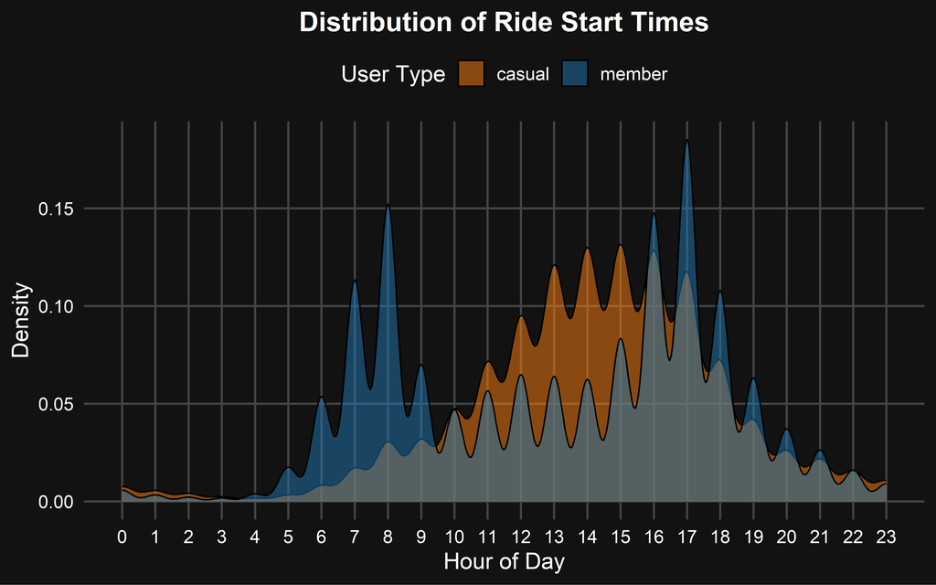

### 3.5 Top Casual Rider Stations

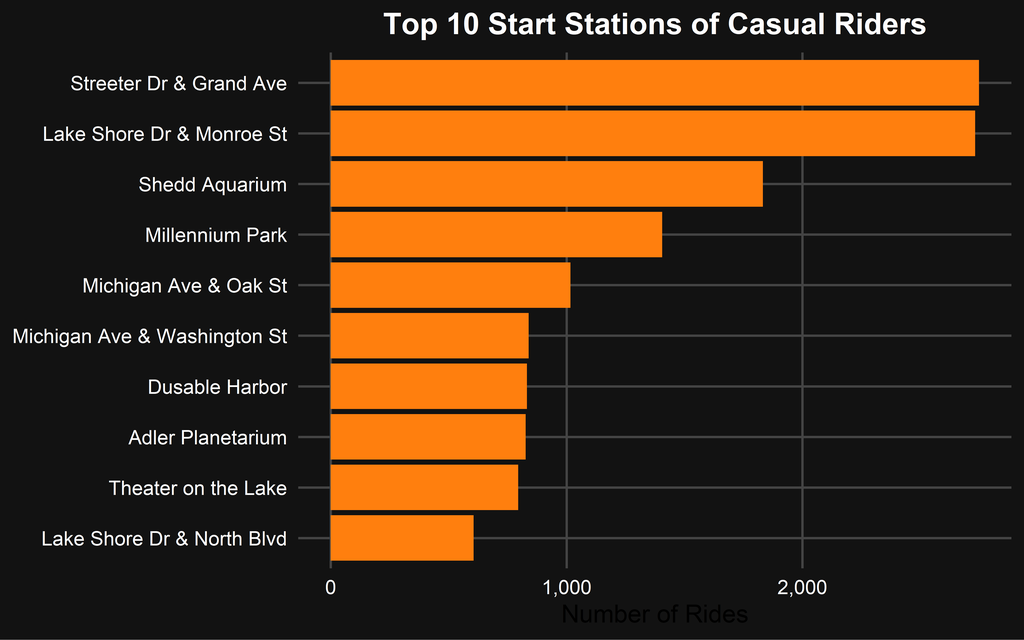

## 4 Recommendations

1. **Convert casual riders to members** – promote discounted weekend membership plans at lakefront-adjacent stations.
2. **Re-deploy capacity** – add docks/bike capacity at top casual stations during summer weekends to meet demand spikes.
3. **Targeted marketing** – push in-app notifications highlighting scenic routes to casual riders during peak leisure hours.
4. **Infrastructure partnerships** – collaborate with the city to improve signage and bike lanes near tourist areas to further encourage casual ridership.

## 5 Next Steps

- Conduct similar analysis on **post-2020 data** to measure pandemic impact and recovery.
- Integrate **weather data** for a more nuanced demand forecast.
- Explore reintegrating **location data** into data collections for use in targeting specific locations.

```r
#  Set echo = TRUE so technical readers can review full script
#  (The code above in setup chunk is repeated here for transparency)
```

[output not shown]